# 36-315 Lab 01

Eu Jing Chua

Due Saturday, August 31, 2019 (6:30pm)

## Lab 01: Hello, world! Introduction to R, RStudio, & RMarkdown

*General instructions for all assignments*:

- Use this file as the template for your submission. Delete the unnecessary text (e.g. this text, the problem statements, etc). That said, keep the nicely formatted “Problem 1”, “Problem 2”, “a.”, “b.”, etc
- Upload a single `R` Markdown file (named as: [AndrewID]-315-Lab01.Rmd – e.g. “larry-315-Lab01.Rmd”) to the Lab 01 submission section on Canvas. You do not need to upload the .html file.
- The instructor and TAs will run your .Rmd file on their computer. **If your .Rmd file does not knit on our computers, you will be automatically get 0 points.**
- Your file should contain the code to answer each question in its own code block. Your code should produce plots/output that will be automatically embedded in the output (.html) file
- Each answer must be supported by written statements (unless otherwise specified)
- Include the name of anyone you collaborated with at the top of the assignment
- Include the style guide you used at the top of the assignment

Here is a graph"

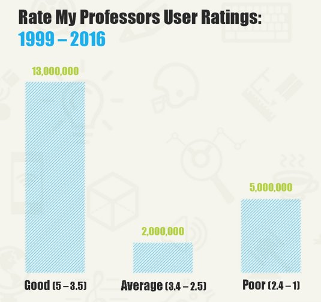

# Problem 1

(15 points)

```r
# I am printing 'Hello, World!' in R Markdown.
# I major in stats and machine learning
print("Hello, World! My name is Eu Jing Chua")
```

```
## [1] "Hello, World! My name is Eu Jing Chua"
```

# Problem 2

(15 points)

**Getting Started**: Create a single code block that contains R commands to do all of the following:

1. $(6+3)*4 - 5$
2. $4^2$
3. $e^{-5}$ (hint: type `help(exp)` at the command line in R Studio
4. Let $y = 8$. Let $x = 5-6y$. Print $x$.
5. Repeat (d) for $y = 0$, $y = 1$, and $y = 5/6$.

```r
(6 + 3) * 4 - 5
```

```
## [1] 31
```

```r
4^2
```

```
## [1] 16
```

```r
exp(-5)
```

```
## [1] 0.00673794699909
```

```r
y <- 8
x <- 5 - 6 * y
x
```

```
## [1] -43
```

```r
y <- 0
x <- 5 - 6 * y
x
```

```
## [1] 5
```

```r
y <- 1
x <- 5 - 6 * y
x
```

```
## [1] -1
```

```r
y <- 5 / 6
x <- 5 - 6 * y
x
```

```
## [1] 0
```

# Problem 3

(15 points)

**Built-in Help and Documentation**: Using the `help()` and `help.search()` functions at the command line, use R to do the following:

1. Find the help documentation for the `quantile` function. This function takes a vector of numbers and computes quantiles for the vectors. What is the description of the `probs` argument?

probs: numeric vector of probabilities with values in [0,1]. (Values up to ‘2e-14’ outside that range are accepted and moved to the nearby endpoint.)

2. Find the help documentation for the `mean` function. This function takes a vector of numbers and computes their average. What is the example code at the bottom of the help page?

```r
 x <- c(0:10, 50)
 xm <- mean(x)
 c(xm, mean(x, trim = 0.10))
```

```
## [1] 8.75 5.50
```

3. Use the help pages to find the name of the function in `R` that finds the standard deviation of a vector, and apply it to the data from b.

```r
sd(x)
```

```
## [1] 13.3697419571
```

Note that because everything is online, you can use online search engines to achieve many of these same goals. Feel free to do so for all of your future assignments.

# Problem 4

(15 points)

1. Load the `MASS` library into R. Open the help documentation for the MASS package. What is the official name of this `MASS` package? It may help to use `library(help = MASS)` to solve this problem.

```r
library(MASS)
```

The official name is Modern Applied Statistics with S.

2. Load the `datasets` library. Find the help documentation for its `trees` dataset. Describe this dataset using information from the help pages.

```r
library(datasets)
data(trees)
```

This data set provides measurements of the diameter, height and volume of timber in 31 felled black cherry trees. Note that the diameter (in inches) is erroneously labelled Girth in the data. It is measured at 4 ft 6 in above the ground.

3. Load the `graphics` library into `R` and open its help documentation. This library is full of graphics/visualization functions that we may use in this class. Find a function that creates a 1-D Scatterplot. Describe its argument `x`.

```r
library(graphics)
```

The function is plot.

x: the coordinates of points in the plot. Alternatively, a single plotting structure, function or *any R object with a ‘plot’ method* can be provided.

# Problem 5

(15 points)

**Installing Packages**

1. At the command line / Console (NOT in a code block), type `install.packages("tidyverse")`. What happens?

The package installed with no problems.

# Problem 6

(25 points)

**Reading, Manipulating, and Plotting Data**

We will use the `read_csv()` function to read in a dataset from the internet. We’ll use the dataset at [https://raw.githubusercontent.com/mateyneykov/315_code_data/master/data/bridges-pgh.csv] for this lab.

1. Load the `tidyverse` library.
2. Read in the “Pittsburgh Bridges” dataset.
3. Create a new column in the dataset that indicates whether the bridge crosses the Allegheny River (“yes” or “no”).
4. Create a new column in the dataset that indicates whether the bridge is at least 3000 feet long (“long” or “short”).
5. Create a well-labled bar plot of the `river` variable.

Although we provided the code for you here, it is important that you take some time to understand what the code does! Study it in detail, and be prepared to do similar tasks in subsequent assignments.

```r
# Load the tidyverse library
library(tidyverse)

# Read in the data
bridges <- read_csv("https://raw.githubusercontent.com/mateyneykov/315_code_data/master/data/bridges-pgh.csv")
```

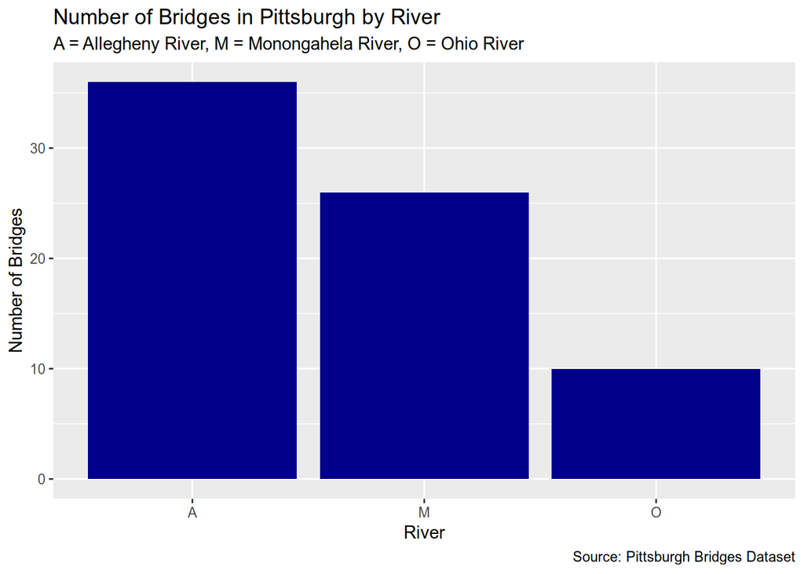

```r
# Create the new variables
bridges <- mutate(bridges,
   over_allegheny = ifelse(river ==  "A", "yes", "no"),
   length_binary = ifelse(length >=  3000, "long", "short"))

# Create the bar plot
ggplot(bridges, aes(x = river)) +
 geom_bar(fill = "darkblue") +
 labs(
 title = "Number of Bridges in Pittsburgh by River",
 subtitle = "A = Allegheny River, M = Monongahela River, O = Ohio River",
 x = "River",
 y = "Number of Bridges",
 caption = "Source: Pittsburgh Bridges Dataset"
 )
```